# Recommendations with IBM

In this notebook, I will use recommendation skills on real data from the IBM Watson Studio platform.

Below you can find the content table of the different methods I created for making recommendations that can be used for different situations.

I. Exploratory Data Analysis  
II. Rank Based Recommendations  
III. User-User Based Collaborative Filtering  
IV. Matrix Factorization  
V. Extras & Concluding

Let's get started by importing the necessary libraries and reading in the data.

```python
import pandas as pd
import numpy as np
import matplotlib.pyplot as plt
import project_tests as t
import pickle
import progressbar       #will need to run 'pip install progressbar' from the terminal
import time


%matplotlib inline

df = pd.read_csv('data/user-item-interactions.csv')
df_content = pd.read_csv('data/articles_community.csv')
del df['Unnamed: 0']
del df_content['Unnamed: 0']
```

```python
#Test timing and progress bar function
import time
from tqdm import tqdm
from tqdm import tqdm_gui
for i in tqdm(range(10)):
    time.sleep(3)
```

```python
# Show df to get an idea of the data
df.head()
```

|  | article_id | title | email |
| --- | --- | --- | --- |
| 0 | 1430.0 | using pixiedust for fast, flexible, and easier... | ef5f11f77ba020cd36e1105a00ab868bbdbf7fe7 |
| 1 | 1314.0 | healthcare python streaming application demo | 083cbdfa93c8444beaa4c5f5e0f5f9198e4f9e0b |
| 2 | 1429.0 | use deep learning for image classification | b96a4f2e92d8572034b1e9b28f9ac673765cd074 |
| 3 | 1338.0 | ml optimization using cognitive assistant | 06485706b34a5c9bf2a0ecdac41daf7e7654ceb7 |
| 4 | 1276.0 | deploy your python model as a restful api | f01220c46fc92c6e6b161b1849de11faacd7ccb2 |

```python
# Show df_content to get an idea of the data
df_content.head()
```

|  | doc_body | doc_description | doc_full_name | doc_status | article_id |
| --- | --- | --- | --- | --- | --- |
| 0 | Skip navigation Sign in SearchLoading...\r\n\r... | Detect bad readings in real time using Python ... | Detect Malfunctioning IoT Sensors with Streami... | Live | 0 |
| 1 | No Free Hunch Navigation * kaggle.com\r\n\r\n ... | See the forest, see the trees. Here lies the c... | Communicating data science: A guide to present... | Live | 1 |
| 2 | ☰ * Login\r\n * Sign Up\r\n\r\n * Learning Pat... | Here’s this week’s news in Data Science and Bi... | This Week in Data Science (April 18, 2017) | Live | 2 |
| 3 | DATALAYER: HIGH THROUGHPUT, LOW LATENCY AT SCA... | Learn how distributed DBs solve the problem of... | DataLayer Conference: Boost the performance of... | Live | 3 |
| 4 | Skip navigation Sign in SearchLoading...\r\n\r... | This video demonstrates the power of IBM DataS... | Analyze NY Restaurant data using Spark in DSX | Live | 4 |

### Part I : Exploratory Data Analysis

Below I provide some insight into the descriptive statistics of the data.

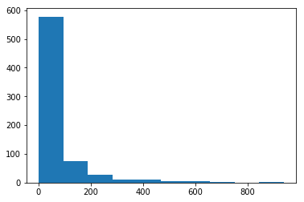

```python
plt.hist(df['article_id'].value_counts(), bins=10)
```

```python
# 50% of individuals have X or fewer article interactions: median_val
median_val = 3

print('50% of individuals interact with {} number of articles or fewer'.format(median_val))
```

```
50% of individuals interact with 3 number of articles or fewer
```

```python
# The maximum number of user-article interactions by any 1 user is: max_views_by_user: max_views_by_user
max_views_by_user_array = df['email'].value_counts()
max_views_by_user = max_views_by_user_array[0]
print('The maximum number of user-article interactions by any 1 user is: {}'.format(max_views_by_user))
```

```
The maximum number of user-article interactions by any 1 user is: 364
```

`2.` Explore and remove duplicate articles from the **df_content** dataframe.

```python
# Find and explore duplicate articles
# Remove any rows that have the same article_id - only keep the first
dup_rows = np.array(df_content[df_content['article_id'].duplicated()].index)

# Drop duplicate rows found
df_content.drop(dup_rows, inplace=True)
df_content.shape
```

```
(1051, 5)
```

`3.` Continuing with our data exploration, we can find:

**a.** The number of unique articles that have an interaction with a user.  
**b.** The number of unique articles in the dataset (whether they have any interactions or not).  
**c.** The number of unique users in the dataset. (excluding null values)  
**d.** The number of user-article interactions in the dataset.

```python
#a. The number of unique articles that have an interaction with a user: unique_articles
unique_articles = df['article_id'].value_counts().count()
print('Total number of unique articles that have at least one interaction: {}'.format(unique_articles))
```

```
Total number of unique articles that have at least one interaction: 714
```

```python
#b. The number of unique articles in the dataset (whether they have any interactions or not): total_articles
total_articles = df_content['article_id'].value_counts().count()
print('Total number of unique articles on the IBM platform: {}'.format(total_articles))
```

```
Total number of unique articles on the IBM platform: 1051
```

```python
#c. The number of unique users in the dataset. (excluding null values): unique_users
unique_users = df['email'].value_counts().count()
print('The number of unique users in the dataset is: {}'.format(unique_users))
```

```
The number of unique users in the dataset is: 5148
```

```python
#d. The number of user-article interactions in the dataset: user_article_interactions
user_article_interactions = df.shape[0]
print('The total number of user-article interactions in the dataset is: {}'.format(user_article_interactions))
```

```
The total number of user-article interactions in the dataset is: 45993
```

`4.` Let's find the most viewed **article_id**, as well as how often it was viewed. After talking to the company leaders, the `email_mapper` function was deemed a reasonable way to map users to ids. There were a small number of null values, and it was found that all of these null values likely belonged to a single user (which is how they are stored using the function below).

```python
# The most viewed article in the dataset as a string with one value following the decimal: most_viewed_article_id
most_viewed_article_id = str(df['article_id'].value_counts().index[0])
print('The most viewed article in the dataset as a string: {}'.format(most_viewed_article_id))
```

```
The most viewed article in the dataset as a string: 1429.0
```

```python
# The most viewed article in the dataset was viewed _____ times.`': max_views
max_views = np.array(df['article_id'].value_counts())[0]
print('The most viewed article in the dataset was viewed {} times'.format(max_views))
```

```
The most viewed article in the dataset was viewed 937 times
```

```python
#map the user email to a user_id column and remove the email column

def email_mapper():
    coded_dict = dict()
    cter = 1
    email_encoded = []

    for val in df['email']:
        if val not in coded_dict:
            coded_dict[val] = cter
            cter+=1

        email_encoded.append(coded_dict[val])
    return email_encoded

email_encoded = email_mapper()
del df['email']
df['user_id'] = email_encoded

# show header
df.head()
```

[output not shown]

### Part II: Rank-Based Recommendations

One issue we have here is we don't actually have ratings for whether a user liked an article or not. We only know that a user has interacted with an article. In these cases, the popularity of an article can really only be based on how often an article was interacted with.

`1.` Below we will find the top articles ordered with most interactions as the top.

```python
def get_top_articles(n, df=df):
    '''
    INPUT:
    n - (int) the number of top articles to return
    df - (pandas dataframe) df as defined at the top of the notebook

    OUTPUT:
    top_articles - (list) A list of the top 'n' article titles

    '''
    top_article_ids = []
    top_articles=[]

    if n > 0:
        try:
            top_article_ids = np.array(df['article_id'].value_counts().index)[:n]

            for i in top_article_ids:

                top_articles.append(df[df['article_id'] == i]['title'].values[0])

        except:
            pass


    return top_articles # Return the top article titles from df (not df_content)
```

```python
def get_top_article_ids(n, df=df):
    '''
    INPUT:
    n - (int) the number of top articles to return
    df - (pandas dataframe) df as defined at the top of the notebook

    OUTPUT:
    top_articles - (list) A list of the top 'n' article titles

    '''
    top_article_ids=[]

    if n > 0:
        try:
            top_article_ids = np.array(df['article_id'].value_counts().index)[:n]

        except:
            pass

    return top_article_ids # Return the top article ids
```

```python
print(get_top_articles(10))
print(get_top_article_ids(10))
```

```
['use deep learning for image classification', 'insights from new york car accident reports', 'visualize car data with brunel', 'use xgboost, scikit-learn & ibm watson machine learning apis', 'predicting churn with the spss random tree algorithm', 'healthcare python streaming application demo', 'fin…
[ 1429.  1330.  1431.  1427.  1364.  1314.  1293.  1170.  1162.  1304.]
```

### Part III: User-User Based Collaborative Filtering

`1.` Now we will reformat the **df** dataframe to be shaped with users as the rows and articles as the columns that have the following properties:

- Each **user** should only appear in each **row** once.
- Each **article** should only show up in one **column**.
- **If a user has interacted with an article, then place a 1 where the user-row meets for that article-column**. It does not matter how many times a user has interacted with the article, all entries where a user has interacted with an article should be a 1.
- **If a user has not interacted with an item, then place a zero where the user-row meets for that article-column**.

```python
# create the user-article matrix with 1's and 0's

def create_user_item_matrix(df):
    '''
    INPUT:
    df - pandas dataframe with article_id, title, user_id columns

    OUTPUT:
    user_item - user item matrix

    Description:
    Return a matrix with user ids as rows and article ids on the columns with 1 values where a user interacted with
    an article and a 0 otherwise
    '''

    n_pairs = len(df['user_id'].values)

    cnter = 0
    bar = progressbar.ProgressBar(maxval=n_pairs+1,
                                  widgets=[progressbar.Bar('=', '[', ']'), ' ', progressbar.Percentage()])
    bar.start()


    read_articles = df['article_id'].value_counts().index

    user_item = df.groupby(['user_id', 'article_id'])['title'].max().unstack()

    userid_list = user_item.index
    acticleId_list = user_item.columns

    user_item[acticleId_list] = 0      #reset all column entries to zero

    start=time.time()
    for i,j in zip(df['user_id'].values, df['article_id'].values):

        t1=time.time()
        if j in read_articles and user_item.loc[i, j] == 0:
#            print('Found item at: {} x {}'.format(i, j))
            # Update the progress bar
            cnter+=1
            bar.update(cnter)

    #        print(i,j)
            user_item.loc[i, j] = 1
            t2=time.time()
#           print('   Time to add: {}'.format(t2-t1))

    bar.finish()
    finish=time.time()
    print('Total Run Time: {}'.format(finish-start))



    return user_item # return the user_item matrix
```

```python
#Change type to 'Code' to run:

user_item = create_user_item_matrix(df)
```

```python
#Change type to 'Code' to run:

#Write previously compiled 'user_item' dataframe
with open('user_item.p', 'wb') as handle:
    pickle.dump(user_item, handle, protocol=pickle.HIGHEST_PROTOCOL)
```

```python
# Load the user_item matrix here
user_item = pd.read_pickle('user_item_matrix.p')
```

`2.` Below is a function that takes a user_id and provide an ordered list of the most similar users to that user (from most similar to least similar). The returned result will not contain the provided user_id, as we know that each user is similar to him/herself. Because the results for each user here are binary, I computed similarity as the dot product of two users.

```python
def find_similar_users(user_id, user_item=user_item):
    '''
    INPUT:
    user_id - (int) a user_id
    user_item - (pandas dataframe) matrix of users by articles:
                1's when a user has interacted with an article, 0 otherwise

    OUTPUT:
    similar_users - (list) an ordered list where the closest users (largest dot product users)
                    are listed first

    Description:
    Computes the similarity of every pair of users based on the dot product
    Returns an ordered

    '''
    # compute similarity of each user to the provided user
    user_content = np.array(user_item)
    dot_prod_users = user_content.dot(np.transpose(user_content))
    user_idx = np.where(user_item.index == user_id)[0][0]

    # sort by similarity
    similar_idxs = np.argsort(dot_prod_users[user_idx])[::-1]


    # remove user_id own user's id
    similar_idxs = similar_idxs[similar_idxs != user_id-1]

    #translate indices to users from df
    most_similar_users = np.array(df.iloc[similar_idxs, ]['user_id'])

    return most_similar_users # return a list of the users in order from most to least similar
```

`3.` Since we have a function that provides the most similar users to each user, we can now use these users to find articles you can recommend to each user.

```python
df.head()
```

|  | article_id | title | user_id |
| --- | --- | --- | --- |
| 0 | 1430.0 | using pixiedust for fast, flexible, and easier... | 1 |
| 1 | 1314.0 | healthcare python streaming application demo | 2 |
| 2 | 1429.0 | use deep learning for image classification | 3 |
| 3 | 1338.0 | ml optimization using cognitive assistant | 4 |
| 4 | 1276.0 | deploy your python model as a restful api | 5 |

```python
def get_article_names(article_ids, df=df, new_user=False):

    '''
    INPUT:
    article_ids - (list) a list of article ids
    df - (pandas dataframe) df as defined at the top of the notebook

    OUTPUT:
    article_names - (list) a list of article names associated with the list of article ids
                    (this is identified by the title column)
    new_user - (boolean) a flag to indicate if the user_id passed is new or existing

    '''
    article_names = []

    if len(article_ids) > 0:

        for id in article_ids:
            if type(id) is str:
                id = float(id)

            try:
    #            article_name = df[df['article_id'] == id]['title'].values[0]
                articles_df = pd.DataFrame(df.groupby(['article_id', 'title']).size().reset_index(name='Freq'))
                article_name = list(articles_df.loc[articles_df['article_id'] == id]['title'])[0]
                article_names.append(article_name)

            except:
                pass

    else:
        if not new_user:
            print('You need to provide at least one item for me to find an article!')

    return article_names # Return the article names associated with list of article ids
```

```python
def get_user_articles(user_id, user_item=user_item, new_user=False):
    '''
    INPUT:
    user_id - (int) a user id
    user_item - (pandas dataframe) matrix of users by articles:
                1's when a user has interacted with an article, 0 otherwise
    new_user - (boolean) a flag to indicate if the user_id passed is new or existing

    OUTPUT:
    article_ids - (list) a list of the article ids seen by the user
    article_names - (list) a list of article names associated with the list of article ids
                    (this is identified by the doc_full_name column in df_content)

    Description:
    Provides a list of the article_ids and article titles that have been seen by a user
    '''
    article_ids = []
    article_names = []


    if not new_user:

        for id in article_ids:
            if type(id) is str:
                id = float(id)


#        article_ids = df[df['user_id'] == user_id]['article_id'].unique()
#        article_ids = list(map(str, article_ids))
        article_ids = df[df['user_id'] == user_id]['article_id'].value_counts()
        article_ids = list(map(str, np.array(article_ids.index)))
        article_names = get_article_names(article_ids, new_user=new_user)


    else:
        article_ids = get_top_article_ids(10)
        article_names = get_top_articles(10)

    return article_ids, article_names # return the ids and names
```

```python
def user_user_recs(user_id, m=10):
    '''
    INPUT:
    user_id - (int) a user id
    m - (int) the number of recommendations you want for the user

    OUTPUT:
    recs - (list) a list of recommendations for the user

    Description:
    Loops through the users based on closeness to the input user_id
    For each user - finds articles the user hasn't seen before and provides them as recs
    Does this until m recommendations are found

    Notes:
    Users who are the same closeness are chosen arbitrarily as the 'next' user

    For the user where the number of recommended articles starts below m
    and ends exceeding m, the last items are chosen arbitrarily

    '''
    recs_id = []
    recs = []
    common_ids = []
    count = 0

    #Get userid's closest neighbours ids and pull my own viewed articles
    similar_users = find_similar_users(user_id)
    my_article_ids, my_article_names = get_user_articles(user_id)


    #Loops through the users based on closeness to the input user_id
    #For each user - finds articles the user hasn't seen before and provides them as recs
    for user in similar_users[:]:

        if count < m:

            art_ids, art_names = get_user_articles(user)

            #Separate each article id in recommend list or already viewed list
            for idx in art_ids:

                #Check to see if article is already viewed or previously added to rec list arbitrarily
                if idx not in my_article_ids:
                    recs_id.append(idx)

            count = len(list(set(recs_id)))

    # Find only the uniques article ids after going thru all similar's articles or m recs found
    recs_id = list(set(recs_id))


    return recs_id[:m] # return your recommendations for this user_id
```

```python
# Check Results
get_article_names(user_user_recs(1, 10)) # Return 10 recommendations for user 1
```

```
['i am not a data scientist – ibm watson data lab',
 'some random weekend reading',
 'housing (2015): united states demographic measures',
 'using machine learning to predict parking difficulty',
 'use decision optimization to schedule league games',
 'use the cloudant-spark connector in python notebook',
 'predicting gentrification using longitudinal census data',
 'using github for project control in dsx',
 "a kaggler's guide to model stacking in practice",
 'self-service data preparation with ibm data refinery']
```

`4.` Now we are going to improve the consistency of the **user_user_recs** function from above.

- Instead of arbitrarily choosing when we obtain users who are all the same closeness to a given user - choose the users that have the most total article interactions before choosing those with fewer article interactions.
- Instead of arbitrarily choosing articles from the user where the number of recommended articles starts below m and ends exceeding m, choose articles with the articles with the most total interactions before choosing those with fewer total interactions. This ranking will be what would be obtained from the **top_articles** function above.

```python
def get_article_interaction(user_id, df=df):
    '''
    INPUT:
    user_id - (int) user_id you want to find the total user-article interactions, including repeats
    df - (pandas dataframe) df as defined at the top of the notebook


    OUTPUT:
    ttl_usr_interactions - (int) total user-article interactions from user-article interactions for any
                                specific user_id passed. Return 0 interactions if user_id isn't found

    Other Details - helper function to assist in 'get_top_sorted_users' function when creating
                    the neighbors_df dataframe.
    '''


    try:
        sort_article_df = pd.DataFrame(df['user_id'].value_counts())
        sort_article_idx = pd.DataFrame(df['user_id'].value_counts()).index
        sort_article_df['article_id'] = sort_article_idx
        sort_article_df.rename(columns={'user_id':'userid_count', 'article_id': 'user_id'}, inplace=True)
        ttl_usr_interactions = sort_article_df.loc[user_id]['userid_count']

    except:
        ttl_usr_interactions=0

    return int(ttl_usr_interactions)
```

```python
def get_top_sorted_users(user_id, df=df, user_item=user_item, new_user=False):
    '''
    INPUT:
    user_id - (int)
    df - (pandas dataframe) df as defined at the top of the notebook
    user_item - (pandas dataframe) matrix of users by articles:
            1's when a user has interacted with an article, 0 otherwise
    new_user - (boolean) a flag to indicate if the user_id passed is new or existing

    OUTPUT:
    neighbors_df - (pandas dataframe) a dataframe with:
                    neighbor_id - is a neighbor user_id
                    similarity - measure of the similarity of each user to the provided user_id
                    num_interactions - number of articles viewed by neighbor_id, excluding already viewed by user_id

    Other Details - sort the neighbors_df by the similarity and then by number of interactions where
                    highest of each is higher in the dataframe

    '''

    neighbors_dict = {'neighbor_id': [],
                      'similarity': [],
                      'num_interactions': [],
                      'rec_ids': []}




    #Check if user_id exists
#    if user_id in user_item.index:
    if not new_user:

        #Create the dot-product matrix for all article similarities
        user_content = np.array(user_item)
        dot_prod_users = user_content.dot(np.transpose(user_content))


        #Get similarity dot-product neighbor ids sorted by most common articles viewed by user_id
        user_idx = np.where(user_item.index == user_id)[0][0]
        neighbors_array = dot_prod_users[user_idx]


    else:
        #Since no existing user we will pass sum of all userid-item interaction and sort by index
        neighbors_array = np.array(user_item.sum(axis=1))

    #=========================================================

    neighbor_id = np.argsort(neighbors_array)[::-1]+1 #add 1 since this is array index to get userid

    #Get userid articles to use for comparison with neighbors
    #Will return empty lists if this is a new user
    my_article_ids, my_article_names = get_user_articles(user_id, new_user=new_user)



    #Loops through the users which is sorted by closeness to the input user_id
    #Get all user articles skipping the first user which would be the target userid
    for user in neighbor_id[:50]:

        rec_ids = []

        #Get article stats for each neighbor
        art_ids, art_names = get_user_articles(user, new_user=False)

        #Find the number of common articles from dot-product array by user index
        common_articles = neighbors_array[user-1]

        #Make a Similiarity metric for each neighbor user
        #Get the total articles in user_item matrix, should be 714
        #Take the size of common_ids and divide by total articles to get a 'similarity percentage'
        similiarity_percent = round(common_articles/neighbors_array.max()*100,2)
        ttl_usr_interactions = get_article_interaction(user)

        #Filter out of total articles any from target user_id previously viewed
        rec_ids = [x for x in art_ids if x not in my_article_ids]


        #print('For user: {:>5}, total articles: {:>3}, unique common articles: {:>4}, similiarity: {:>5}%'.format(user, len(ttl_ids), len(rec_ids), similiarity_percent))

        #Insert into Neighbor dictionary
        neighbors_dict['neighbor_id'].append(user)
        neighbors_dict['similarity'].append(similiarity_percent)
        neighbors_dict['num_interactions'].append(ttl_usr_interactions)
        neighbors_dict['rec_ids'].append(rec_ids)


    #Convert the compiled dictionary to dataframe
    neighbors_df = pd.DataFrame({'neighbor_id': neighbors_dict['neighbor_id'],
                                 'similarity %': neighbors_dict['similarity'],
                                 'num_interactions': neighbors_dict['num_interactions'],
                                 'rec_ids' : neighbors_dict['rec_ids']})


    #=========================================================

    if not new_user:

        #Sort dataframe by similarity and number of interactions, remove first row which is always target userid
        neighbors_df = neighbors_df.sort_values(['similarity %', 'num_interactions'])[::-1][1:]


    else:
        #Sort dataframe by similarity and number of interactions, remove first row which is always target userid
        neighbors_df = neighbors_df.sort_values(['num_interactions'])[::-1]


    return neighbors_df # Return the dataframe specified in the doc_string
```

```python
def user_user_recs_part2(user_id, m=10, new_user=False):
    '''
    INPUT:
    user_id - (int) a user id
    m - (int) the number of recommendations you want for the user

    OUTPUT:
    recs - (list) a list of recommendations for the user by article id
    rec_names - (list) a list of recommendations for the user by article title

    '''

    recs = []
    rec_names = []

    # Get similar userids neighbor dataframe
    # Here we will choose the users that have the most total article interactions
    neighbors_df = get_top_sorted_users(user_id, new_user=new_user)

    neighbors_users = np.array(neighbors_df['neighbor_id'])

    # Loops through the users based on closeness to the input user_id
    # For each user - finds articles the user hasn't seen before and provides them as recs
    # Does this until m recommendations are found


    #Choose articles with the articles with the most total interactions before choosing
    #those with fewer total interactions. We have already sorted neighbors_df by interactions
    #And we already captured unique articles not previously view in 'rec_ids' column
    #So once we locate the user in neighbors_users we just get first 'rec_ids' articl

    for ii, user in enumerate(neighbors_users):

        if len(set(recs)) < m:

            if not new_user:
                try:
                    recs.append(neighbors_df.loc[neighbors_df['neighbor_id'] == user]['rec_ids'].values[0][0])
                except:
                    pass

            #only taking the top ranked article based on user-article interactions
            else:

                #recs.append(neighbors_df.iloc[ii]['rec_ids'][0])
                recs = get_top_article_ids(m)
                m+=1

    recs = list(set(map(str, recs)))
    rec_names = get_article_names(recs)


    return recs, rec_names
```

```python
# Quick spot check - don't change this code - just use it to test your functions
rec_ids, rec_names = user_user_recs_part2(20, 10)
print("The top 10 recommendations for user 20 are the following article ids:")
print(rec_ids)
print()
print("The top 10 recommendations for user 20 are the following article names:")
print(rec_names)
```

```
The top 10 recommendations for user 20 are the following article ids:
['1170.0', '1274.0', '1314.0', '1293.0', '1402.0', '1330.0', '1186.0', '609.0', '1400.0', '1427.0']

The top 10 recommendations for user 20 are the following article names:
['apache spark lab, part 1: basic concepts', 'data model with streaming analytics and python', 'healthcare python streaming application demo', 'finding optimal locations of new store using decision optimization', 'uci: adult - predict income', 'insights from new york car accident reports', 'connect …
```

`5.` We will use our functions to test if our solutions look correct.

```python
#The user that is most similar to user 1:
get_top_sorted_users(1).head(1)
```

|  | neighbor_id | similarity % | num_interactions | rec_ids |
| --- | --- | --- | --- | --- |
| 1 | 3933 | 97.22 | 45 | [] |

```python
#The user that is the 10th most similar to user 131:
get_top_sorted_users(131).head(10)
```

|  | neighbor_id | similarity % | num_interactions | rec_ids |
| --- | --- | --- | --- | --- |
| 1 | 3870 | 98.67 | 144 | [195.0] |
| 2 | 3782 | 52.00 | 363 | [43.0, 29.0, 1172.0, 1330.0, 1305.0, 943.0, 48... |
| 3 | 23 | 50.67 | 364 | [29.0, 43.0, 1172.0, 1305.0, 1330.0, 943.0, 21... |
| 5 | 203 | 44.00 | 160 | [241.0, 1396.0, 1060.0, 1298.0, 32.0, 1056.0, ... |
| 4 | 4459 | 44.00 | 158 | [1060.0, 1396.0, 241.0, 510.0, 428.0, 1061.0, ... |
| 6 | 98 | 38.67 | 170 | [1175.0, 1274.0, 116.0, 164.0, 730.0, 1324.0, ... |
| 7 | 3764 | 38.67 | 169 | [1175.0, 1274.0, 116.0, 164.0, 51.0, 651.0, 73... |
| 9 | 49 | 38.67 | 147 | [1274.0, 681.0, 936.0, 1393.0, 1330.0, 1337.0,... |
| 8 | 3697 | 38.67 | 145 | [1274.0, 681.0, 936.0, 1393.0, 1337.0, 315.0, ... |
| 10 | 242 | 33.33 | 148 | [1170.0, 1172.0, 1437.0, 1183.0, 109.0, 1391.0... |

```python
### Tests with a dictionary of results

user1_most_sim = 3933 # Find the user that is most similar to user 1
user131_10th_sim = 242 # Find the 10th most similar user to user 131
```

`7.` Using our existing functions, I will provide the top 10 recommended articles that would be provided for a new users below.

```python
new_user = '0.0'

# What would your recommendations be for this new user '0.0'?  As a new user, they have no observed articles.
# Provide a list of the top 10 article ids you would give to
new_user_recs = list(map(str, get_top_article_ids(10)))
new_user_recs
```

```
['1429.0',
 '1330.0',
 '1431.0',
 '1427.0',
 '1364.0',
 '1314.0',
 '1293.0',
 '1170.0',
 '1162.0',
 '1304.0']
```